# Estimating spatial survival with OPSCR models and nimbleSCR

### 1.5 Create data, constants and inits objects

```r
nimConstants <- list(M = M,
                     n.years = n.years,
                     n.years1 = n.years-1,
                     n.traps = dim(scaledObjects$coordsDataScaled)[1],
                     y.max = dim(habitatMask)[1],
                     x.max = dim(habitatMask)[2],
                     y.maxDet = dim(trapLocal$habitatGrid)[1],
                     x.maxDet = dim(trapLocal$habitatGrid)[2],
                     ResizeFactor = trapLocal$resizeFactor,
                     n.cells = dim(trapLocal$localIndices)[1],
                     maxNBDets = trapLocal$numLocalIndicesMax,
                     trapIndex = trapLocal$localIndices,
                     nTraps = trapLocal$numLocalIndices,
                     habitatIDDet = trapLocal$habitatGrid,
                     lengthYCombined = lengthYCombined,
                     numHabWindows = dim(lowerAndUpperCoords$lowerHabCoords)[1],
                     maxNBDetsReco = deadObsLocal$numLocalIndicesMax)



nimData <- list(trapCoords = scaledObjects$coordsDataScaled,
                trials = rep(1, dim(scaledObjects$coordsDataScaled)[1]),
                lowerHabCoords = lowerAndUpperCoords$lowerHabCoords,
                upperHabCoords = lowerAndUpperCoords$upperHabCoords,
                habitatGrid = lowerAndUpperCoords$habitatGrid,
                detReco = rep(1, dim(lowerAndUpperCoords$lowerHabCoords)[1]),
                habCov = habCov,
                mu = rep(1, dim(lowerAndUpperCoords$lowerHabCoords)[1]),
                habitatGridLocal = deadObsLocal$habitatGrid,
                localObsWindowIndices = deadObsLocal$localIndices,
                numLocalObsWindows = deadObsLocal$numLocalIndices,
                resizeFactor = deadObsLocal$resizeFactor
                )

# We set the parameter values as inits
nimInits <- list(sigma = sigma,
                 p0=p0,
                 tau=tau,
                 gamma = gamma[2:n.years],
                 gamma1 = gamma[1],
                 mhW = mhW,
                 mhH = mhH,
                 betaH = betaH,
                 betaW = betaW)
```

### 1.6 Create NIMBLE model

```r
model <- nimbleModel( code = modelCode,
                      constants = nimConstants,
                      data = nimData,
                      inits = nimInits,
                      check = F,
                      calculate = F)
```

### 1.7 Simulate SCR data from the NIMBLE model

Using NIMBLE function ‘getDependencies’, we obtain the list of nodes to be be simulated. Using the ‘simulate’ function from NIMBLE, we then simulate the activity center (AC) locations (‘s’), the state of the individual (‘z’) and SCR observation data (‘y’; ‘y.dead’).

```r
# FIRST WE GET THE NODES TO SIMULATE
nodesToSim <- model$getDependencies(c("p0","sigma","mhW", "mhH","mu",
                                      "gamma","tau","gamma1","betaH",
                                       "betaW"),
                                      self = F,
                                      downstream = T,
                                      returnScalarComponents = TRUE)
# THEN WE SIMULATE THOSE NODES
set.seed(1)
model$simulate(nodesToSim, includeData = FALSE)
```

After running ‘simulate’, the simulated data are stored in the ‘model’ object. For example, we can access the simulated ‘z’ and check how many individuals were considered alive and recovered at each time step:

```r
N <- apply(model$z,2,function(x)sum(x==2))
N
```

```
## [1] 188 185 183 184 193
```

```r
N.recoveredDead <- apply(model$z,2,function(x)sum(x==3))
N.recoveredDead
```

```
## [1]  0 24 36 38 31
```

## 2. RUN MCMC WITH NIMBLE

Here, we build the NIMBLE model again using the simulated ‘y’ and ‘y.dead’ as data. For simplicity, we used the simulated ‘z’ as initial values. Then we can fit the OPSCR model with the simulated ‘y’ and ‘y.dead’ data sets.

```r
myZ <- model$z
z <- zInits <- model$z
whichDet <- apply(model$y, 3, function(x) x[,1]>0 )
whichNotDet <- apply(model$y, 3, function(x) x[,1]==0 )

# give NAS to individuals not detected
z[whichNotDet] <- NA
zInits[whichDet] <- NA

nimData$y <- model$y
nimData$y.dead <- model$y.dead

nimData$z <- z
nimInits$z <- zInits
nimInits$s <- model$s

# CREATE AND COMPILE THE NIMBLE MODEL
model <- nimbleModel( code = modelCode,
                      constants = nimConstants,
                      data = nimData,
                      inits = nimInits,
                      check = F,
                      calculate = F)
model$calculate()
```

```
## [1] -15865.97
```

```r
cmodel <- compileNimble(model)
cmodel$calculate()
MCMCconf <- configureMCMC(model = model,
                          monitors = c("p0","sigma","mhW","mhH", "N",
                                         "gamma","tau","betaH","betaW"),
                          control = list(reflective = TRUE),
                          thin = 1)
## WE NEED TO SET A CATEGORICAL SAMPLER FOR THE NODES USED BY dcatState1Alive2Dead
## FIND WHICH Z NODES NEED TO BE REPLACED BY THE NEW SAMPLER.
samplerConfList <- unlist(lapply(MCMCconf$getSamplers(),function(x) x$target))
zNodes <- samplerConfList[grep("z",samplerConfList)]
## FIND Z NODES FROM THE FIRST YEAR (SHOULD NOT BE REPLACED)
zNodes <- zNodes[-grep( ", 1]",zNodes)]

MCMCconf
#remove samplers
MCMCconf$removeSamplers(zNodes)
MCMCconf$addSampler(target = zNodes,
                      type = 'sampler_categorical_general',
                      scalarComponents = TRUE,
                      control = list("numCategories"= 4))
MCMC <- buildMCMC(MCMCconf)
cMCMC <- compileNimble(MCMC, project = model, resetFunctions = TRUE)
# RUN THE MCMC
MCMCRuntime <- system.time(myNimbleOutput <- runMCMC( mcmc = cMCMC,
                                                             nburnin = 1000,
                                                             niter = 5000,
                                                             nchains = 3,
                                                             samplesAsCodaMCMC = TRUE))
```

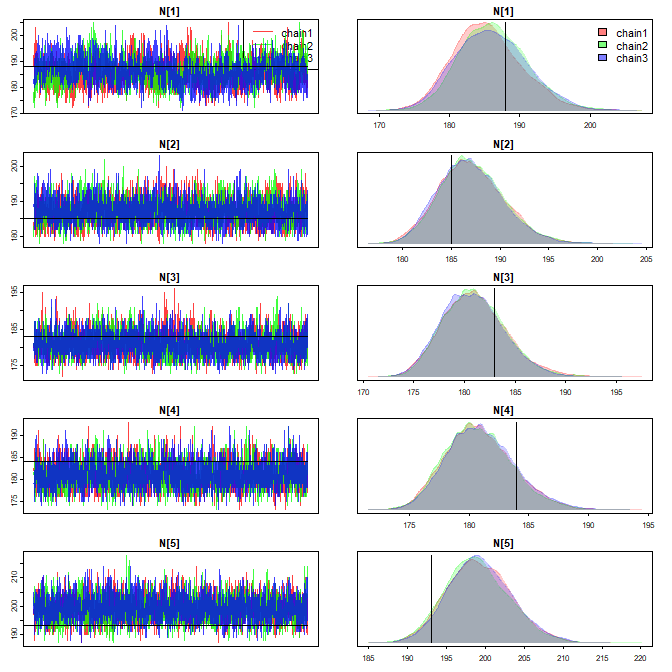

```r
load("samples.RData")

#plot check
chainsPlot(myNimbleOutput, var=c("N[1]","N[2]","N[3]","N[4]","N[5]"), line = N)
```

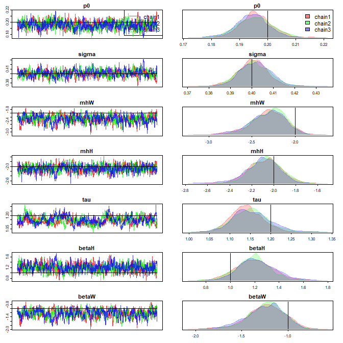

```r
chainsPlot(myNimbleOutput, var=c("p0","sigma","mhW","mhH","tau","betaH","betaW"),
           line= c(p0, sigma, mhW, mhH, tau, betaH, betaW))
```

## REFERENCES

Bischof, Richard, Daniel Turek, Cyril Milleret, Torbjorn Ergon, Pierre Dupont, and Perry de Valpine. 2020. *nimbleSCR: Spatial Capture-Recapture (SCR) Methods Using ’Nimble’*.

de Valpine, Perry, Daniel Turek, Christopher J Paciorek, Clifford Anderson-Bergman, Duncan Temple Lang, and Rastislav Bodik. 2017. “Programming with Models: Writing Statistical Algorithms for General Model Structures with NIMBLE.” *J. Comput. Graph. Stat.* 26 (2): 403–13.

Dupont, P., C. Milleret, M. Tourani, H. Brøseth, and R. Bischof. 2021. “Integrating Dead Recoveries in Open-Population Spatial Capture–Recapture Models.” *Ecosphere* 12 (7): e03571. https://doi.org/https://doi.org/10.1002/ecs2.3571.

Milleret, Cyril, Pierre Dupont, Christophe Bonenfant, Henrik Brøseth, Øystein Flagstad, Chris Sutherland, and Richard Bischof. 2019. “A Local Evaluation of the Individual State-Space to Scale up Bayesian Spatial Capture–Recapture.” *Ecology and Evolution* 9 (1): 352–63. https://doi.org/10.1002/ece3.4751.

NIMBLE Development Team. 2020. “NIMBLE: MCMC, Particle Filtering, and Programmable Hierarchical Modeling.” https://doi.org/10.5281/zenodo.1211190.

Royle, J Andrew, and Robert M Dorazio. 2012. “Parameter-Expanded Data Augmentation for Bayesian Analysis of Capture–Recapture Models.” *Journal of Ornithology* 152 (2): 521–37.

Turek, Daniel, Cyril Milleret, Torbjørn Ergon, Henrik Brøseth, Pierre Dupont, Richard Bischof, and Perry de Valpine. 2021. “Efficient Estimation of Large-Scale Spatial Capture–Recapture Models.” *Ecosphere* 12 (2): e03385. https://doi.org/https://doi.org/10.1002/ecs2.3385.